# Post 4 - Classification

- Show All Code
- Hide All Code
- View Source

code

data visualization

Author

Charan Teja Chelle

Published

November 19, 2023

# Introduction

Classification is another type of supervised learning in machine learning where the primary objective is to get trained on a labeled dataset in order to predict the class or category of an object or instance. For instance, consider a classification model is trained on a dataset of images labeled as either lions or tigers and then it will predict the class of unseen, new images of lions or tigers solely based on their features such as appearance, color, and shape. Classification is of two types namely Binary (classify input into one of two classes) and Multiclass (classify input into one of several classes) classification. Various types of classification algorithms include Logistic Regression, K-Nearest Neighbors, Naive Bayes, Decision Trees etc., Spam detection and handwriting recognition are some of the real-time applications of classification in machine learning.

# Code

```
Accuracy: 0.93
Classification Report:
               precision    recall  f1-score   support

           0       1.00      1.00      1.00        10
           1       1.00      0.78      0.88         9
           2       0.85      1.00      0.92        11

    accuracy                           0.93        30
   macro avg       0.95      0.93      0.93        30
weighted avg       0.94      0.93      0.93        30
```

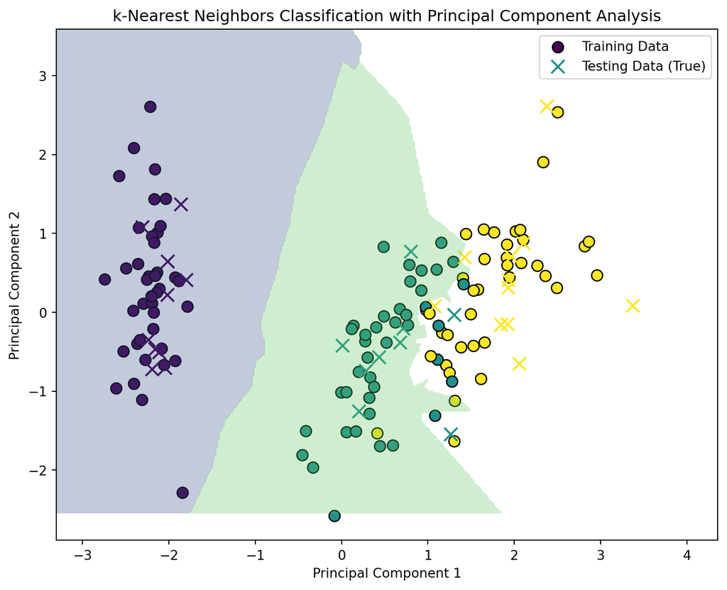

```python
import numpy as np
import matplotlib.pyplot as plot
from sklearn import datasets
from sklearn.neighbors import KNeighborsClassifier
from sklearn.preprocessing import StandardScaler
from sklearn.metrics import accuracy_score, classification_report
from sklearn.model_selection import train_test_split
from sklearn.decomposition import PCA

# Load the Iris dataset
iris = datasets.load_iris()
X = iris.data
y = iris.target

# Splitting the derived data into training and testing sets
X_train, X_test, y_train, y_test = train_test_split(X, y, test_size=0.2, random_state=42)

# Standardize the features (it's completely optional but often beneficial)
scaler = StandardScaler()
X_train_std = scaler.fit_transform(X_train)
X_test_std = scaler.transform(X_test)

# Apply Principal Component Analysis (PCA) for dimensionality reduction to two components
pca = PCA(n_components=2)
X_train_pca = pca.fit_transform(X_train_std)
X_test_pca = pca.transform(X_test_std)

# Train a k-Nearest Neighbors classifier
knn_classifier = KNeighborsClassifier(n_neighbors=3)
knn_classifier.fit(X_train_pca, y_train)

# Make predictions on the test set
y_pred = knn_classifier.predict(X_test_pca)

# Evaluate the accuracy of the classifier
accuracy = accuracy_score(y_test, y_pred)
print(f'Accuracy: {accuracy:.2f}')

# Visualize the decision boundaries
plot.figure(figsize=(9, 7))

# Plot the training points
plot.scatter(X_train_pca[:, 0], X_train_pca[:, 1], c=y_train, cmap='viridis', edgecolor='k', s=70, label='Training Data')

# Plot the testing points
plot.scatter(X_test_pca[:, 0], X_test_pca[:, 1], c=y_test, cmap='viridis', marker='x', s=100, label='Testing Data (True)')

# Plot the decision boundaries
h = 0.02  # step size in the mesh
x_min, x_max = X_test_pca[:, 0].min() - 1, X_test_pca[:, 0].max() + 1
y_min, y_max = X_test_pca[:, 1].min() - 1, X_test_pca[:, 1].max() + 1
xx, yy = np.meshgrid(np.arange(x_min, x_max, h), np.arange(y_min, y_max, h))
Z = knn_classifier.predict(np.c_[xx.ravel(), yy.ravel()])
Z = Z.reshape(xx.shape)

# Plot the decision boundaries
plot.contourf(xx, yy, Z, cmap='viridis', alpha=0.3, levels=np.arange(len(np.unique(y))) - 0.5)

# Add labels and title
plot.title('k-Nearest Neighbors Classification with Principal Component Analysis')
plot.xlabel('Principal Component 1')
plot.ylabel('Principal Component 2')

# Add legend
plot.legend()

# Display the results
plot.show()

# Display classification report
print('Classification Report:\n', classification_report(y_test, y_pred))
```